# Milestone Report

Trevor Aeschliman

February 7,2017

## Getting the Data

The data must first be downloaded from the Coursera Capstone web page. It includes a news, blogs, and twitter file for 4 languages. This project will be using only the English files.

Once the file has been downloaded, set the working directory to the directory which contains the file. Then, using readLines, the files are opened up to be viewed in R.

### Read Files

```r
setwd("C:/Users/trevo/Desktop/datascience/Capstone/final/en_US")
blogs<-readLines("en_US.blogs.txt", skipNul=TRUE)
twitter<-readLines("en_US.twitter.txt",skipNul=TRUE)
news<-readLines("en_US.news.txt",skipNul=TRUE)
```

## Examining the data

Looking at the data, you can see that the files are simply 3 large text files. We first look at numerical information about the text, including number of lines and number of words.

Number of lines per file

```r
length(blogs)
```

```
## [1] 899288
```

```r
length(twitter)
```

```
## [1] 2360148
```

```r
length(news)
```

```
## [1] 77259
```

Number of Words per File

```r
library(stringi)
blogCount<-stri_count(blogs,regex="\\S+")
twitterCount<-stri_count(twitter,regex="\\S+")
newsCount<-stri_count(news,regex="\\S+")
sum(blogCount)
```

```
## [1] 37334441
```

```r
sum(twitterCount)
```

```
## [1] 30373832
```

```r
sum(newsCount)
```

```
## [1] 2643972
```

## Sampling the Data

We take samples from each of the three files, trying to make the samples roughly the same size so that the resulting file is evenly composed of news, twitter, and blog text. We are going to check our word frequencies and n-grams on these samples.

```r
# Take a sample of a similar size from each source.
set.seed(222)
sample.blogs<-sample(blogs,length(blogs)*.025)
sample.twitter<-sample(twitter,length(twitter)*.01)
sample.news<-sample(news,length(news)*.25)

sample0<-c(sample.blogs,sample.twitter,sample.news)
```

## Cleaning the Data

```r
library(tm)
```

```r
library(ggplot2)
library(RWeka)

#Removing the non-ascii characters that are in place of the apostrophe
sample0<-gsub("[^A-Za-z][^A-Za-z][^A-Za-z]","'",sample0)

#Using tm library
text0 <- VCorpus(VectorSource(sample0))
text0 <- tm_map(text0, tolower)
text0 <- tm_map(text0, removePunctuation)
text0 <- tm_map(text0, removeNumbers)
text0 <- tm_map(text0, stripWhitespace)

#Remove stop words and create a new text file
textStopless <- tm_map(text0, removeWords, stopwords("en"))
textStopless<-tm_map(textStopless,PlainTextDocument)
textStopless <- tm_map(textStopless, content_transformer(function(x, pattern) gsub(pattern, " ", x)), "[^A-Za-z]")

# Finish with the file that retains all stop words
text0 <- tm_map(text0, PlainTextDocument)
text0 <- tm_map(text0, content_transformer(function(x, pattern) gsub(pattern, " ", x)), "[^A-Za-z]")
```

## Exploratory Analysis on File with Stop Words

Two files have been created, one with stop words, and one without. Because phrases with stop words will need to be predicted, it would be beneficial to have an algorithm that works on those words. However, leaving the stop words in lowers the probabilities of other words which need to be considered, so another analysis on a file without stop words will be run. Depending on the efficiency of the prediction algorithm, both may be kept for the final project.

We tokenize the sentences in our sample to separate out all of the words, bigrams, and trigrams in the file, and then place the n-grams in descending order by frequency.

```r
#words
wordMatrix <- TermDocumentMatrix(text0)
freq1 <- sort(rowSums(as.matrix(removeSparseTerms(wordMatrix,0.99))), decreasing = TRUE)
freq1 <- data.frame(word = names(freq1),frequency=freq1)

#bi-grams
bigramToken <- function(x) NGramTokenizer(x, Weka_control(min = 2, max = 2))
bigramMatrix <- TermDocumentMatrix(text0, control = list(tokenize = bigramToken))
freq2 <- sort(rowSums(as.matrix(removeSparseTerms(bigramMatrix,0.99))), decreasing = TRUE)
freq2 <- data.frame(bigram = names(freq2),frequency=freq2)

#tri-grams
trigramToken <- function(x) NGramTokenizer(x, Weka_control(min = 3, max = 3))
trigramMatrix <- TermDocumentMatrix(text0, control = list(tokenize = trigramToken))
freq3 <- sort(rowSums(as.matrix(removeSparseTerms(trigramMatrix,0.999))), decreasing = TRUE)
freq3 <- data.frame(trigram = names(freq3),frequency=freq3)
```

We then plot the frequencies for the top 25 n-grams of each type.

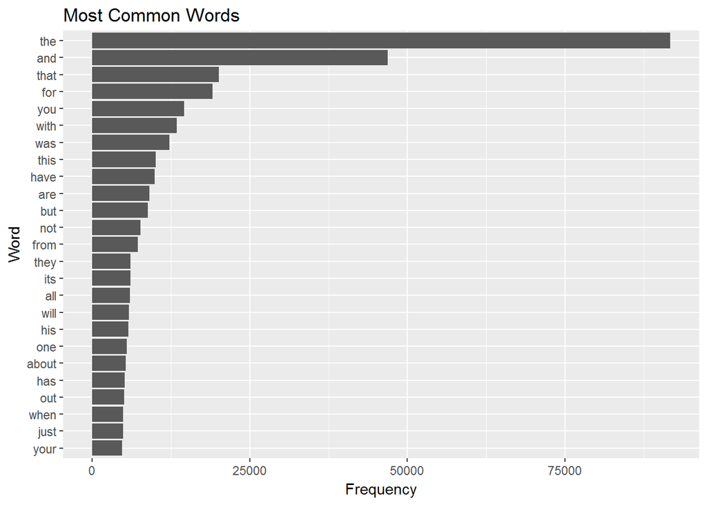

```r
#words
g1<- ggplot(freq1[1:25,],aes(reorder(word, frequency), frequency)) +
        labs(title= "Most Common Words", x = "Word", y = "Frequency") +
        geom_col()+
        coord_flip()
g1
```

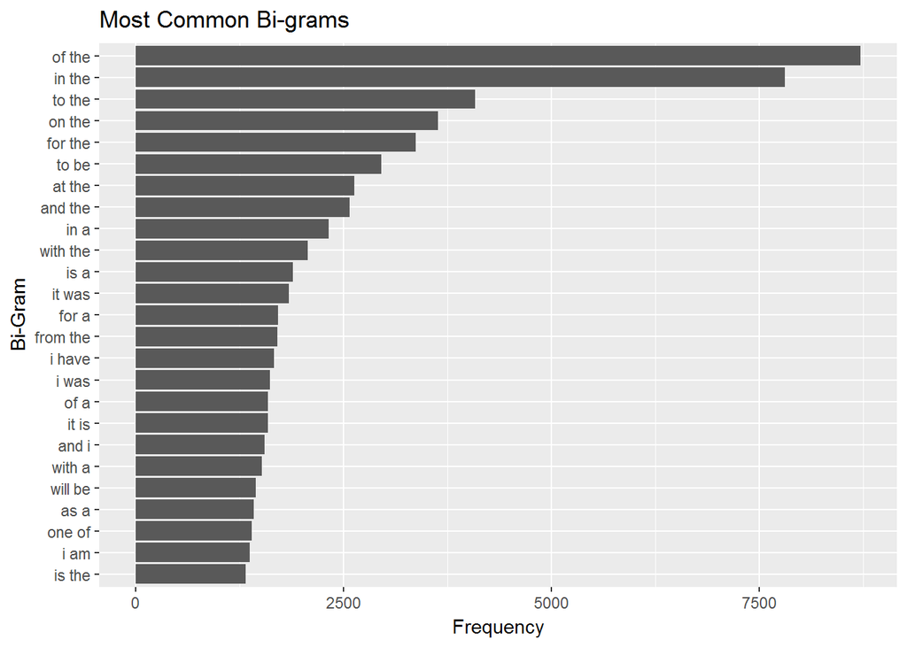

```r
#bi-grams
g2<- ggplot(freq2[1:25,],aes(reorder(bigram, frequency), frequency)) +
        labs(title= "Most Common Bi-grams", x = "Bi-Gram", y = "Frequency") +
        geom_col()+
        coord_flip()
g2
```

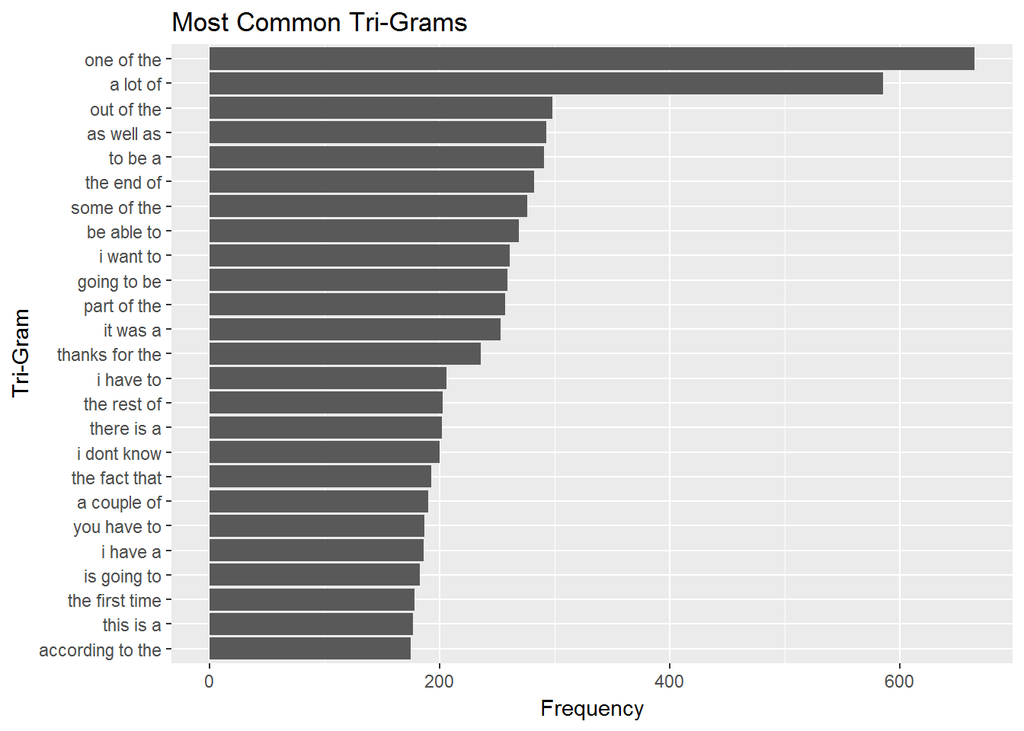

```r
#tri-grams
g3<- ggplot(freq3[1:25,],aes(reorder(trigram, frequency), frequency)) +
        labs(title= "Most Common Tri-Grams", x = "Tri-Gram", y = "Frequency") +
        geom_col()+
        coord_flip()
g3
```

## Exploratory Analysis on File Without Stop Words

```r
#words
wordMatrixS <- TermDocumentMatrix(textStopless)
freq1S <- sort(rowSums(as.matrix(removeSparseTerms(wordMatrixS,0.99))), decreasing = TRUE)
freq1S <- data.frame(word = names(freq1S),frequency=freq1S)

#bi-grams
bigramTokenS <- function(x) NGramTokenizer(x, Weka_control(min = 2, max = 2))
bigramMatrixS <- TermDocumentMatrix(textStopless, control = list(tokenize = bigramTokenS))
freq2S <- sort(rowSums(as.matrix(removeSparseTerms(bigramMatrixS,0.9999))), decreasing = TRUE)
freq2S <- data.frame(bigram = names(freq2S),frequency=freq2S)

#tri-grams
trigramTokenS <- function(x) NGramTokenizer(x, Weka_control(min = 3, max = 3))
trigramMatrixS <- TermDocumentMatrix(textStopless, control = list(tokenize = trigramTokenS))
freq3S <- sort(rowSums(as.matrix(removeSparseTerms(trigramMatrixS,0.9999))), decreasing = TRUE)
freq3S <- data.frame(trigram = names(freq3S),frequency=freq3S)
```

We then plot the frequencies for the top 25 n-grams of each type.

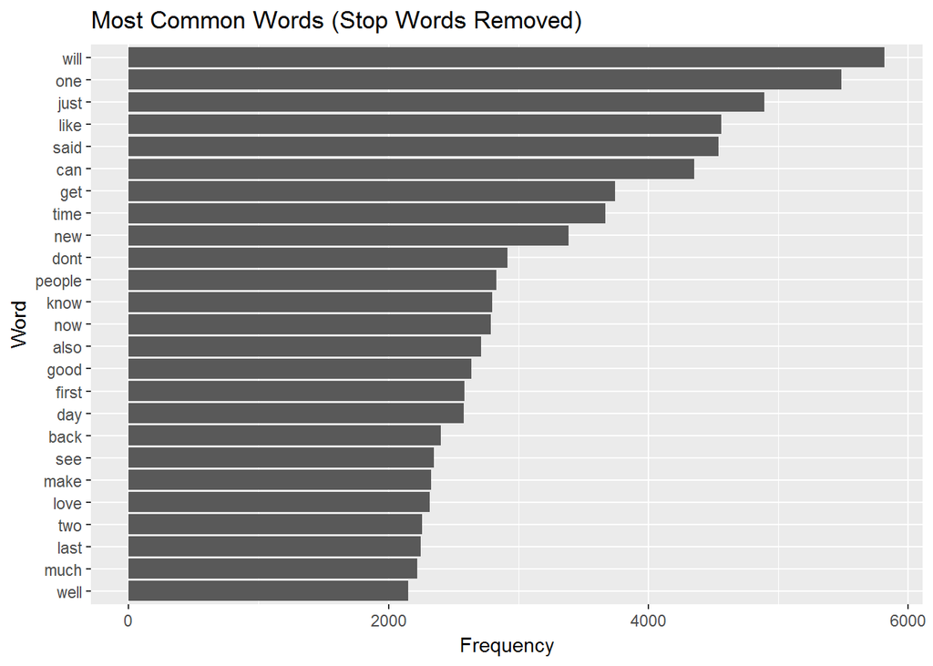

```r
#words
g1S<- ggplot(freq1S[1:25,],aes(reorder(word, frequency), frequency)) +
        labs(title= "Most Common Words (Stop Words Removed)", x = "Word", y = "Frequency") +
        geom_col()+
        coord_flip()
g1S
```

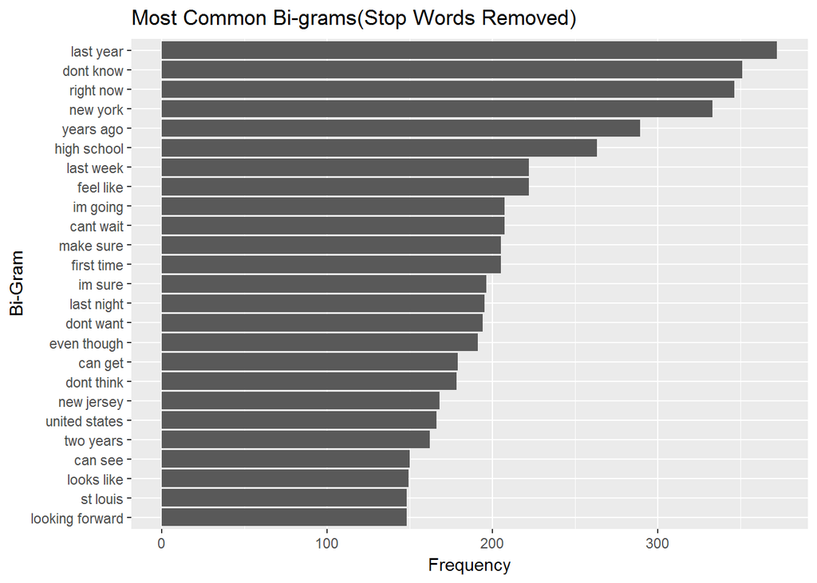

```r
#bi-grams
g2S<- ggplot(freq2S[1:25,],aes(reorder(bigram, frequency), frequency)) +
        labs(title= "Most Common Bi-grams(Stop Words Removed)", x = "Bi-Gram", y = "Frequency") +
        geom_col()+
        coord_flip()
g2S
```

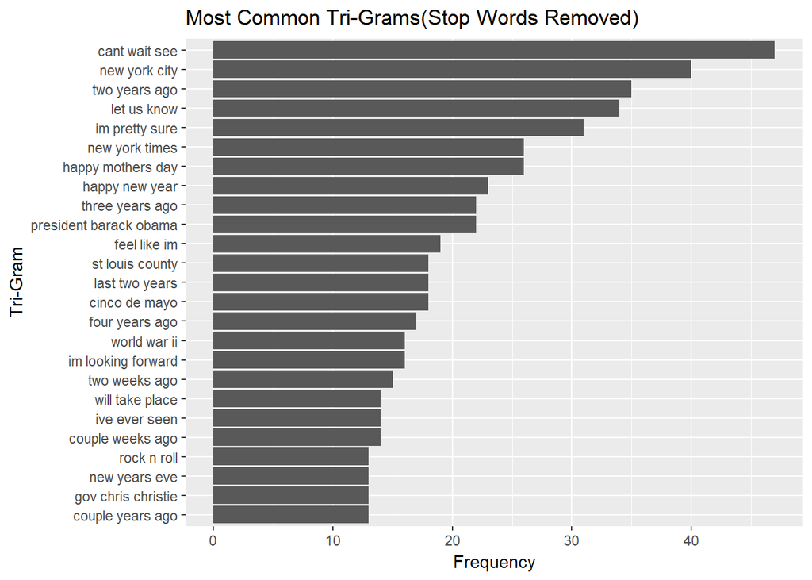

```r
#tri-grams
g3S<- ggplot(freq3S[1:25,],aes(reorder(trigram, frequency), frequency)) +
        labs(title= "Most Common Tri-Grams(Stop Words Removed)", x = "Tri-Gram", y = "Frequency") +
        geom_col()+
        coord_flip()
g3S
```

## Model

Now that we’ve uncovered information about the data sets, using an even sampling from each file, we need to build a predictive model that will take in a word or words and will give a predicted next word or pair of words. To do this, we will search through our n-gram frequency data frames and display the 3 words with the highest probability of occurring next.